# InVivoStat Single Measure Parametric Analysis

## Response

The Resp1 2 response is currently being analysed by the Single Measures Parametric Analysis module.

## Scatterplot of the observed data

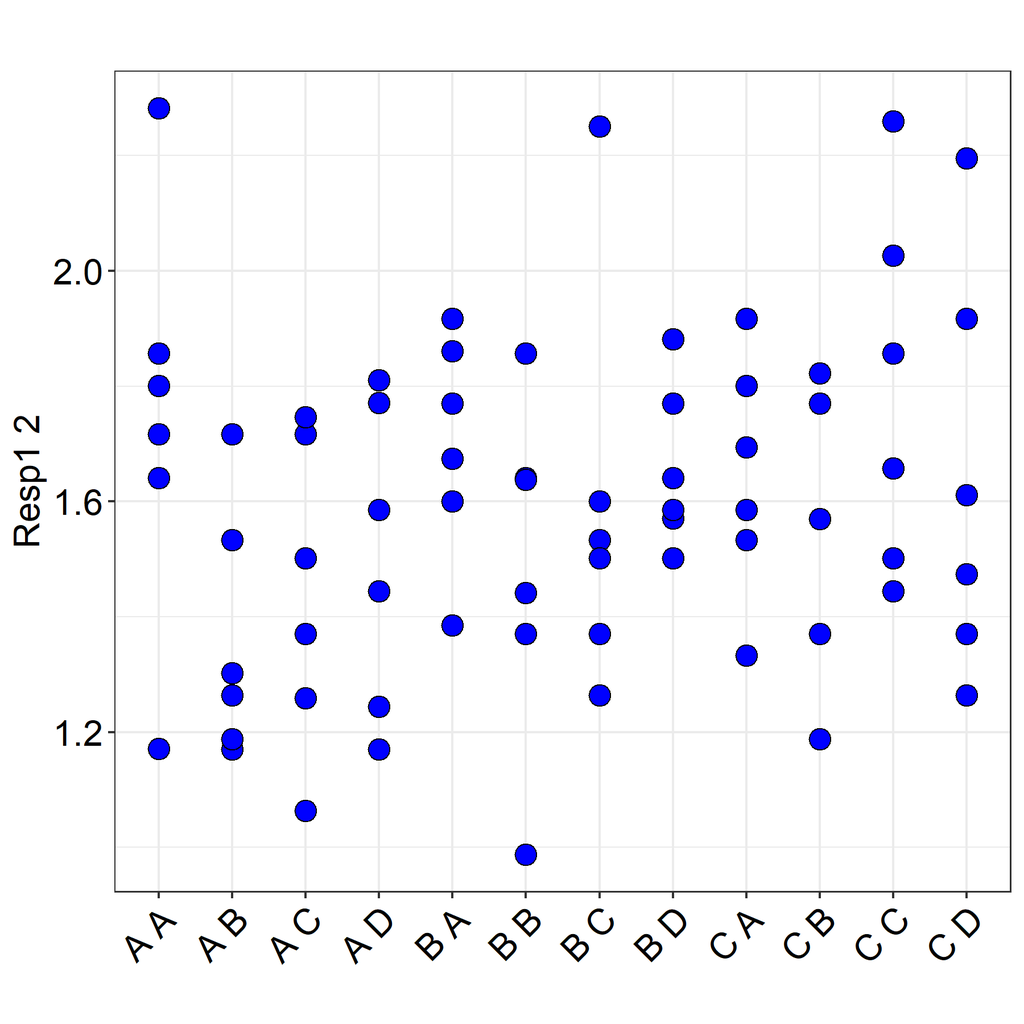

Tip: Use this plot to identify possible outliers.

## Analysis of variance (ANOVA) table

| Effect | Sums of squares | Degrees of freedom | Mean square | F-value | p-value |
| --- | --- | --- | --- | --- | --- |
| Treat 15 | 0.227 | 2 | 0.114 | 1.49 | 0.2339 |
| Treat16 | 0.537 | 3 | 0.179 | 2.34 | 0.0819 |
| Treat 15 * Treat16 | 0.336 | 6 | 0.056 | 0.73 | 0.6255 |
| Residual | 4.583 | 60 | 0.076 |  |  |

Comment: ANOVA table calculated using a Type III model fit, see Armitage et al. (2001).

Conclusion: At the 5% level, there are no statistically significant overall differences between the levels of any of the terms in the ANOVA table.

Tip: While it is a good idea to consider the overall tests in the ANOVA table, we should not rely on them when deciding whether or not to make pairwise comparisons.

## Model coefficients

|  | Estimate | Std. Error | t-value | p-value |
| --- | --- | --- | --- | --- |
| (Intercept) | 1.5898 | 0.0326 | 48.81 | < 0.0001 |
| Treat 151 | -0.0764 | 0.0461 | -1.66 | 0.1026 |
| Treat 152 | 0.0191 | 0.0461 | 0.41 | 0.6803 |
| Treat161 | 0.1068 | 0.0564 | 1.89 | 0.0633 |
| Treat162 | -0.1343 | 0.0564 | -2.38 | 0.0204 |
| Treat163 | 0.0170 | 0.0564 | 0.30 | 0.7641 |
| Treat 151:Treat161 | 0.1245 | 0.0798 | 1.56 | 0.1239 |
| Treat 152:Treat161 | -0.0144 | 0.0798 | -0.18 | 0.8578 |
| Treat 151:Treat162 | -0.0170 | 0.0798 | -0.21 | 0.8321 |
| Treat 152:Treat162 | 0.0146 | 0.0798 | 0.18 | 0.8555 |
| Treat 151:Treat163 | -0.0876 | 0.0798 | -1.10 | 0.2765 |
| Treat 152:Treat163 | -0.0393 | 0.0798 | -0.49 | 0.6245 |

## Diagnostic plots

### Residuals vs. predicted plot

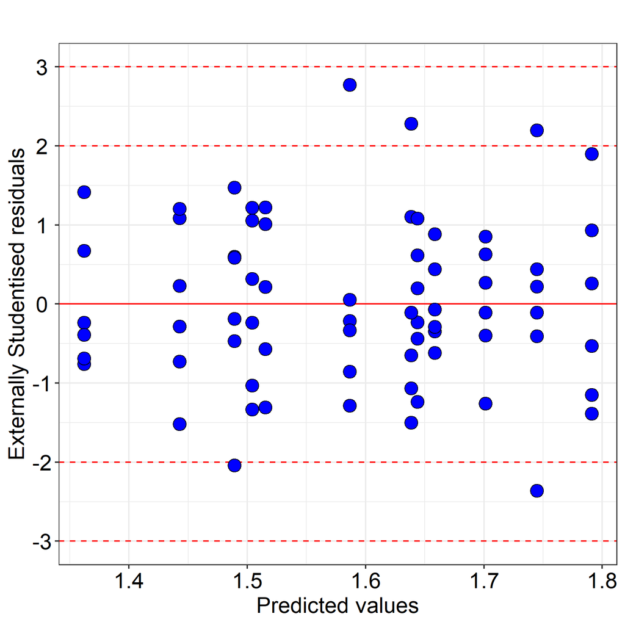

Tip: On this plot look to see if the spread of the points increases as the predicted values increase. If so the response may need transforming.

Tip: Any observation with a residual less than -3 or greater than 3 (SD) should be investigated as a possible outlier.

### Normal probability plot

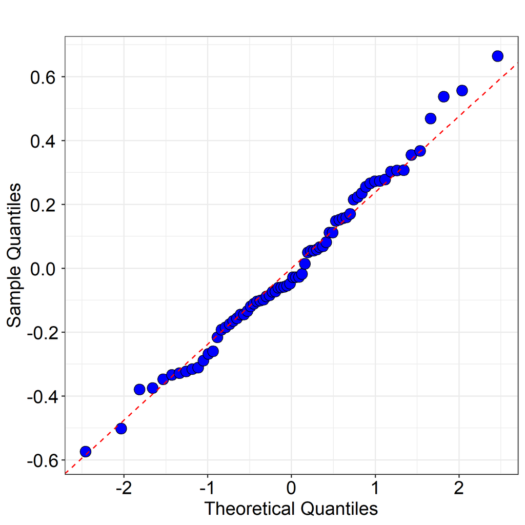

Tip: Check that the points lie along the dotted line. If not then the data may be non-normally distributed.

## Table of the least square (predicted) means with 95% confidence intervals

| Mean ID | Treat 15 | Treat16 | Mean | Lower 95% CI | Upper 95% CI |
| --- | --- | --- | --- | --- | --- |
| 1 | A | A | 1.745 | 1.519 | 1.970 |
| 2 | B | A | 1.701 | 1.476 | 1.927 |
| 3 | C | A | 1.644 | 1.418 | 1.869 |
| 4 | A | B | 1.362 | 1.136 | 1.588 |
| 5 | B | B | 1.489 | 1.263 | 1.715 |
| 6 | C | B | 1.515 | 1.289 | 1.741 |
| 7 | A | C | 1.443 | 1.217 | 1.669 |
| 8 | B | C | 1.587 | 1.361 | 1.812 |
| 9 | C | C | 1.791 | 1.565 | 2.017 |
| 10 | A | D | 1.504 | 1.278 | 1.730 |
| 11 | B | D | 1.658 | 1.433 | 1.884 |
| 12 | C | D | 1.639 | 1.413 | 1.864 |

## Plot of the least square (predicted) means with 95% confidence intervals

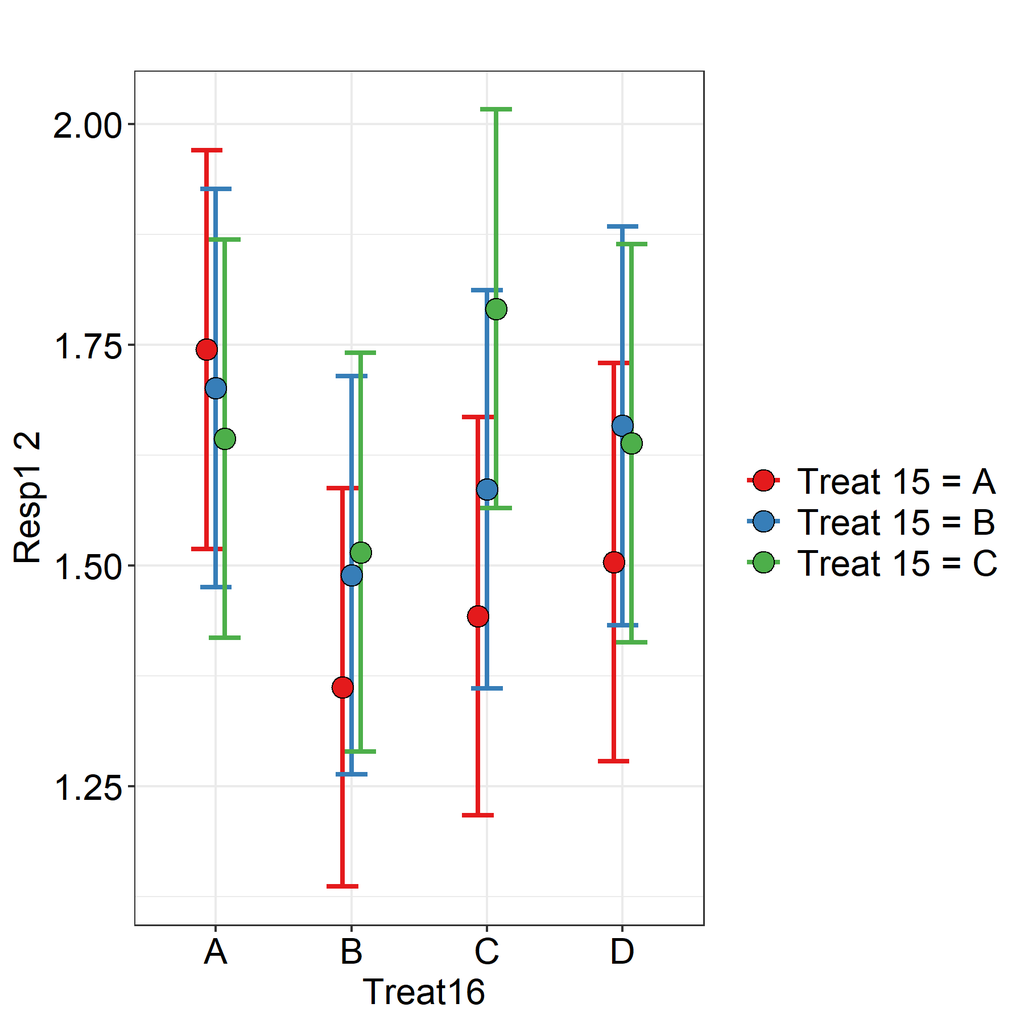

## All pairwise comparisons using Tukey's procedure

| Comparison | Difference | Lower 95% CI | Upper 95% CI | Std error | p-value |
| --- | --- | --- | --- | --- | --- |
| A,A - B,A | 0.043 | -0.276 | 0.363 | 0.160 | 1.0000 |
| A,A - C,A | 0.101 | -0.218 | 0.420 | 0.160 | 1.0000 |
| A,A - A,B | 0.383 | 0.063 | 0.702 | 0.160 | 0.4235 |
| A,A - B,B | 0.256 | -0.064 | 0.575 | 0.160 | 0.9017 |
| A,A - C,B | 0.230 | -0.090 | 0.549 | 0.160 | 0.9506 |
| A,A - A,C | 0.302 | -0.017 | 0.621 | 0.160 | 0.7593 |
| A,A - B,C | 0.158 | -0.161 | 0.477 | 0.160 | 0.9974 |
| A,A - C,C | -0.046 | -0.365 | 0.273 | 0.160 | 1.0000 |
| A,A - A,D | 0.241 | -0.079 | 0.560 | 0.160 | 0.9326 |
| A,A - B,D | 0.086 | -0.233 | 0.405 | 0.160 | 1.0000 |
| A,A - C,D | 0.106 | -0.213 | 0.425 | 0.160 | 0.9999 |
| B,A - C,A | 0.058 | -0.262 | 0.377 | 0.160 | 1.0000 |
| B,A - A,B | 0.339 | 0.020 | 0.658 | 0.160 | 0.6072 |
| B,A - B,B | 0.212 | -0.107 | 0.531 | 0.160 | 0.9717 |
| B,A - C,B | 0.186 | -0.133 | 0.505 | 0.160 | 0.9896 |
| B,A - A,C | 0.258 | -0.061 | 0.578 | 0.160 | 0.8949 |
| B,A - B,C | 0.115 | -0.205 | 0.434 | 0.160 | 0.9999 |
| B,A - C,C | -0.090 | -0.409 | 0.229 | 0.160 | 1.0000 |
| B,A - A,D | 0.197 | -0.122 | 0.516 | 0.160 | 0.9837 |
| B,A - B,D | 0.043 | -0.276 | 0.362 | 0.160 | 1.0000 |
| B,A - C,D | 0.063 | -0.256 | 0.382 | 0.160 | 1.0000 |
| C,A - A,B | 0.282 | -0.038 | 0.601 | 0.160 | 0.8298 |
| C,A - B,B | 0.155 | -0.165 | 0.474 | 0.160 | 0.9978 |
| C,A - C,B | 0.129 | -0.191 | 0.448 | 0.160 | 0.9996 |
| C,A - A,C | 0.201 | -0.118 | 0.520 | 0.160 | 0.9812 |
| C,A - B,C | 0.057 | -0.262 | 0.376 | 0.160 | 1.0000 |
| C,A - C,C | -0.147 | -0.466 | 0.172 | 0.160 | 0.9986 |
| C,A - A,D | 0.140 | -0.180 | 0.459 | 0.160 | 0.9991 |
| C,A - B,D | -0.015 | -0.334 | 0.304 | 0.160 | 1.0000 |
| C,A - C,D | 0.005 | -0.314 | 0.324 | 0.160 | 1.0000 |
| A,B - B,B | -0.127 | -0.446 | 0.192 | 0.160 | 0.9996 |
| A,B - C,B | -0.153 | -0.472 | 0.166 | 0.160 | 0.9980 |
| A,B - A,C | -0.081 | -0.400 | 0.238 | 0.160 | 1.0000 |
| A,B - B,C | -0.225 | -0.544 | 0.095 | 0.160 | 0.9576 |
| A,B - C,C | -0.429 | -0.748 | -0.110 | 0.160 | 0.2577 |
| A,B - A,D | -0.142 | -0.461 | 0.177 | 0.160 | 0.9990 |
| A,B - B,D | -0.296 | -0.616 | 0.023 | 0.160 | 0.7796 |
| A,B - C,D | -0.276 | -0.596 | 0.043 | 0.160 | 0.8459 |
| B,B - C,B | -0.026 | -0.345 | 0.293 | 0.160 | 1.0000 |
| B,B - A,C | 0.046 | -0.273 | 0.365 | 0.160 | 1.0000 |
| B,B - B,C | -0.098 | -0.417 | 0.222 | 0.160 | 1.0000 |
| B,B - C,C | -0.302 | -0.621 | 0.017 | 0.160 | 0.7595 |
| B,B - A,D | -0.015 | -0.334 | 0.304 | 0.160 | 1.0000 |
| B,B - B,D | -0.169 | -0.489 | 0.150 | 0.160 | 0.9952 |
| B,B - C,D | -0.149 | -0.469 | 0.170 | 0.160 | 0.9984 |
| C,B - A,C | 0.072 | -0.247 | 0.391 | 0.160 | 1.0000 |
| C,B - B,C | -0.071 | -0.391 | 0.248 | 0.160 | 1.0000 |
| C,B - C,C | -0.276 | -0.595 | 0.043 | 0.160 | 0.8478 |
| C,B - A,D | 0.011 | -0.308 | 0.330 | 0.160 | 1.0000 |
| C,B - B,D | -0.143 | -0.463 | 0.176 | 0.160 | 0.9989 |
| C,B - C,D | -0.123 | -0.443 | 0.196 | 0.160 | 0.9997 |
| A,C - B,C | -0.144 | -0.463 | 0.175 | 0.160 | 0.9989 |
| A,C - C,C | -0.348 | -0.667 | -0.029 | 0.160 | 0.5687 |
| A,C - A,D | -0.061 | -0.380 | 0.258 | 0.160 | 1.0000 |
| A,C - B,D | -0.216 | -0.535 | 0.104 | 0.160 | 0.9681 |
| A,C - C,D | -0.196 | -0.515 | 0.123 | 0.160 | 0.9846 |
| B,C - C,C | -0.204 | -0.524 | 0.115 | 0.160 | 0.9786 |
| B,C - A,D | 0.083 | -0.237 | 0.402 | 0.160 | 1.0000 |
| B,C - B,D | -0.072 | -0.391 | 0.247 | 0.160 | 1.0000 |
| B,C - C,D | -0.052 | -0.371 | 0.267 | 0.160 | 1.0000 |
| C,C - A,D | 0.287 | -0.032 | 0.606 | 0.160 | 0.8128 |
| C,C - B,D | 0.132 | -0.187 | 0.452 | 0.160 | 0.9995 |
| C,C - C,D | 0.152 | -0.167 | 0.472 | 0.160 | 0.9981 |
| A,D - B,D | -0.154 | -0.474 | 0.165 | 0.160 | 0.9979 |
| A,D - C,D | -0.134 | -0.454 | 0.185 | 0.160 | 0.9994 |
| B,D - C,D | 0.020 | -0.299 | 0.339 | 0.160 | 1.0000 |

Conclusion: At the 5% level, there are no statistically significant pairwise comparisons.

Warning: The results of Tukey's procedure are approximate if the sample sizes are not equal.

Warning: This procedure makes an adjustment assuming you want to make all pairwise comparisons. If this is not the case then these tests may be unduly conservative. You may wish to use planned comparisons (using unadjusted p-values) instead, see Snedecor and Cochran (1989), or make a manual adjustment to the unadjusted p-values using the InVivoStat P-value Adjustment module.

Note: The confidence intervals quoted are not adjusted for multiplicity.

## Analysis description

The data were analysed using a 2-way ANOVA approach, with Treat 15 and Treat16 as the treatment factors. This was followed by all pairwise comparisons between the predicted means of the Treat 15 * Treat16 interaction using Tukey's procedure, Braun (1994).

For more information on the theoretical approaches that are implemented within this module, see Bate and Clark (2014).

## References

When referring to InVivoStat, please cite 'InVivoStat, version 5.2.0'.

Bate, S.T. and Clark, R.A. (2014). The Design and Statistical Analysis of Animal Experiments. Cambridge University Press.

Armitage, P., Matthews, J.N.S. and Berry, G. (2001). Statistical Methods in Medical Research. 4th edition; John Wiley & Sons. New York.

Braun, H.I., ed. (1994). The collected works of John W. Tukey. Vol. VIII: Multiple comparisons:1948-1983. New York: Chapman and Hall.

Snedecor, G.W. and Cochran, W.G. (1989). Statistical Methods. 8th edition; Iowa State University Press, Iowa, USA.